# Problem Statement:

## Model Building

### Model Evaluation Criterion

**Model can make two kinds of wrong predictions:**

1. Predicting that the customer will purchase a Travel Package when they don"t. - False Positive.
2. Predicting that the customer will not purchase a Travel Package when they do. - False Negative.

**The Travel company"s objectives are:**

1. Make Marketing Expenditure more efficient and focused on the customers that would actually purchase the product.
2. Predict and Identify all potential customers who will purchase the newly introduced wellness travel package.

**Metric for Optimization:**

For the above objectives, its important that both False positive and False negative values are low. Hence we would want the F1-Score to be maximized. The greater the F1-Score, greater the chances of predicting both classes correctly.

**We will build following models, tune them and compare the outcome of all the models:**

1. Decision Tree model.
2. Bagging Classifier.
3. Random Forest Classifier.
4. ADABoost.
5. GradientBoost.
6. XG Boost.
7. Stacking Classifier.

**Let's define a function to provide F1 scores on the train and test set and a function to show confusion matrix so that we do not have to use the same code repetitively while evaluating models.**

```python
# defining a function to compute different metrics to check performance of a classification model built using sklearn
def model_performance_classification_sklearn(model, predictors, target):
    """
    Function to compute different metrics to check classification model performance

    model: classifier
    predictors: independent variables
    target: dependent variable
    """

    # predicting using the independent variables
    pred = model.predict(predictors)

    acc = accuracy_score(target, pred)  # to compute Accuracy
    recall = recall_score(target, pred)  # to compute Recall
    precision = precision_score(target, pred)  # to compute Precision
    f1 = f1_score(target, pred)  # to compute F1-score

    # creating a dataframe of metrics
    df_perf = pd.DataFrame(
        {
            "Accuracy": acc,
            "Recall": recall,
            "Precision": precision,
            "F1": f1,
        },
        index=[0],
    )

    return df_perf
```

```python
def add_score_model(score):
  '''add score of modelto list'''
  df_cols = ['score', 'train' , 'test']
  dfScores = pd.DataFrame(columns=df_cols)

  new_row = {'score':'Accuracy', 'train':score[0], 'test':score[1]}
  #append row to the dataframe
  dfScores = dfScores.append(new_row, ignore_index=True)
  new_row = {'score':'Recall', 'train':score[2], 'test':score[3]}
  #append row to the dataframe
  dfScores = dfScores.append(new_row, ignore_index=True)

  new_row = {'score':'Precision', 'train':score[4], 'test':score[5]}
  #append row to the dataframe
  dfScores = dfScores.append(new_row, ignore_index=True)
  new_row = {'score':'F1', 'train':score[6], 'test':score[7]}
  #append row to the dataframe
  dfScores = dfScores.append(new_row, ignore_index=True)
  return dfScores
```

```python
def make_confusion_matrix(y_actual,y_predict,title):
    '''Plot confusion matrix'''
    fig, ax = plt.subplots(1, 1)

    cm = confusion_matrix(y_actual, y_predict, labels=[0,1])
    disp = ConfusionMatrixDisplay(confusion_matrix=cm,
                               display_labels=["No","Yes"])
    disp.plot(cmap='YlOrRd',colorbar=True,ax=ax)

    ax.set_title(title)
    plt.tick_params(axis=u'both', which=u'both',length=0)
    plt.grid(b=None,axis='both',which='both',visible=False)
    plt.show()
```

```python
def get_metrics_score(model,X_train_df,X_test_df,y_train_pass,y_test_pass,flag=True):
    '''
    Function to calculate different metric scores of the model - Accuracy, Recall, Precision, and F1 score
    model: classifier to predict values of X
    train, test: Independent features
    train_y,test_y: Dependent variable
    threshold: thresold for classifiying the observation as 1
    flag: If the flag is set to True then only the print statements showing different will be displayed. The default value is set to True.
    roc: If the roc is set to True then only roc score will be displayed. The default value is set to False.
    '''
    # defining an empty list to store train and test results
    score_list=[]
    pred_train = model.predict(X_train_df)
    pred_test = model.predict(X_test_df)
    pred_train = np.round(pred_train)
    pred_test = np.round(pred_test)
    train_acc = accuracy_score(y_train_pass,pred_train)
    test_acc = accuracy_score(y_test_pass,pred_test)
    train_recall = recall_score(y_train_pass,pred_train)
    test_recall = recall_score(y_test_pass,pred_test)
    train_precision = precision_score(y_train_pass,pred_train)
    test_precision = precision_score(y_test_pass,pred_test)
    train_f1 = f1_score(y_train_pass,pred_train)
    test_f1 = f1_score(y_test_pass,pred_test)
    score_list.extend((train_acc,test_acc,train_recall,test_recall,train_precision,test_precision,train_f1,test_f1))
    if flag == True:
          metric_names = ['Train_Accuracy', 'Test_Accuracy', 'Train_Recall', 'Test_Recall','Train_Precision',
                          'Test_Precision', 'Train_F1-Score', 'Test_F1-Score']
          cols = ['Metric', 'Score']
          records = [(name, score) for name, score in zip(metric_names, score_list)]
          # display(pd.DataFrame.from_records(records, columns=cols, index='Metric').T)
          make_confusion_matrix(y_train_pass,pred_train,"Confusion Matrix for Train")
          make_confusion_matrix(y_test_pass,pred_test,"Confusion Matrix for Test")
          df = add_score_model(score_list)
          # display(df)
          display(pd.DataFrame.from_records(df))
    # return score_list # returning the list with train and test scores
```

## Ensemble Techniques

### Decision Tree

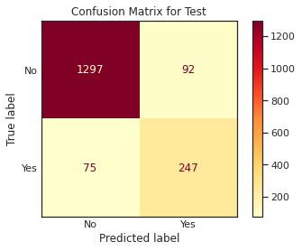

|  | score | train | test |
| --- | --- | --- | --- |
| 0 | Accuracy | 1.0 | 0.902396 |
| 1 | Recall | 1.0 | 0.767081 |
| 2 | Precision | 1.0 | 0.728614 |
| 3 | F1 | 1.0 | 0.747352 |

```python
#Fitting the model
d_tree = DecisionTreeClassifier(random_state=1)
d_tree.fit(X_train,y_train)

#Calculating different metrics
dtree_model_train_perf=model_performance_classification_sklearn(d_tree,X_train,y_train)
dtree_model_test_perf=model_performance_classification_sklearn(d_tree,X_test,y_test)
#Creating confusion matrix
get_metrics_score(d_tree,X_train,X_test,y_train,y_test,True)
```

- The decision tree is overfitting the training data as there is a huge difference between training and test scores for all the metrics.
- F1 score is good around 75%, but the model is overfitting.

[figure not shown]

```python
plt.figure(figsize=(15,10))
feature_names = X_train.columns
out = tree.plot_tree(d_tree,feature_names=feature_names,filled=True,fontsize=9,class_names=['1','0'])
for o in out:
    arrow = o.arrow_patch
    if arrow is not None:
        arrow.set_edgecolor('black')
        arrow.set_linewidth(1)
plt.show()
```

- The tree is extreemly big and scattered, which means the model is overfitting.
- We have to prune this tree by using hyperparameters to get better results.

### Random Forest

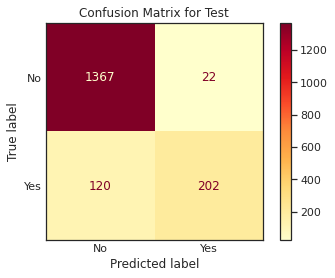

|  | score | train | test |
| --- | --- | --- | --- |
| 0 | Accuracy | 1.0 | 0.917008 |
| 1 | Recall | 1.0 | 0.627329 |
| 2 | Precision | 1.0 | 0.901786 |
| 3 | F1 | 1.0 | 0.739927 |

```python
#Fitting the model
rf_estimator = RandomForestClassifier(random_state=1)
rf_estimator.fit(X_train,y_train)
#Creating confusion matrix
get_metrics_score(rf_estimator,X_train,X_test,y_train,y_test)
#Calculating different metrics
rf_estimator_model_train_perf=model_performance_classification_sklearn(rf_estimator,X_train,y_train)
rf_estimator_model_test_perf=model_performance_classification_sklearn(rf_estimator,X_test,y_test)
```

- Random forest is overfitting the training data as there is a huge difference between training and test scores for all the metrics.
- The test recall is even lower than the decision tree but has a higher test precision, however F1 score is approximately the same value.

### Bagging Classifier

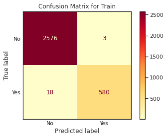

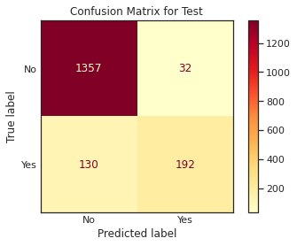

|  | score | train | test |
| --- | --- | --- | --- |
| 0 | Accuracy | 0.993390 | 0.905319 |
| 1 | Recall | 0.969900 | 0.596273 |
| 2 | Precision | 0.994854 | 0.857143 |
| 3 | F1 | 0.982218 | 0.703297 |

```python
#Fitting the model
bagging_classifier = BaggingClassifier(random_state=1)
bagging_classifier.fit(X_train,y_train)

#Calculating different metrics
get_metrics_score(bagging_classifier,X_train,X_test,y_train,y_test)

bagging_classifier_model_train_perf=model_performance_classification_sklearn(bagging_classifier,X_train,y_train)
bagging_classifier_model_test_perf=model_performance_classification_sklearn(bagging_classifier,X_test,y_test)
```

- Bagging classifier giving a similar performance as random forest.
- It is also overfitting the training data and lower test F1 than decision tree and Random Forest.

### Let's try using logistic regression as the base estimator for bagging classifier:

- Now, let's try and change the `base_estimator` of the bagging classifier, which is a decision tree by default.
- We will pass the logistic regression as the base estimator for bagging classifier.

```python
bagging_lr=BaggingClassifier(base_estimator=LogisticRegression(solver='newton-cg',random_state=1,max_iter=1000),random_state=1)
bagging_lr.fit(X_train,y_train)
```

```
BaggingClassifier(base_estimator=LogisticRegression(max_iter=1000,
                                                    random_state=1,
                                                    solver='newton-cg'),
                  random_state=1)
```

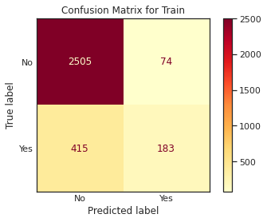

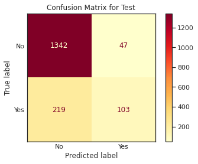

|  | score | train | test |
| --- | --- | --- | --- |
| 0 | Accuracy | 0.846081 | 0.844535 |
| 1 | Recall | 0.306020 | 0.319876 |
| 2 | Precision | 0.712062 | 0.686667 |
| 3 | F1 | 0.428070 | 0.436441 |

```python
#Using above defined function to get accuracy, recall and precision on train and test set
get_metrics_score(bagging_lr,X_train,X_test,y_train,y_test)
bagging_lr_model_train_perf=model_performance_classification_sklearn(bagging_lr,X_train,y_train)
bagging_lr_model_test_perf=model_performance_classification_sklearn(bagging_lr,X_test,y_test)
```

- Logistic Regression doesn't seem to be overfitting, however the F1 test score is extremely low.

### Tuning Decision Tree

```python
#Choose the type of classifier.
dtree_estimator = DecisionTreeClassifier(random_state=1)

parammetersdecisiontree = {
    'max_depth': [2, 3, 5, 7, 9, 12],
    'min_samples_leaf': [1, 2, 5, 7, 10],
    'criterion': ["gini", "entropy"],
    'class_weight' : [{1:0.6, 0:0.4}, {1:0.7, 0:0.3}, {1:0.8, 0:0.2}, {1:0.5, 0:0.5},'balanced']
    ,'max_leaf_nodes' : [2, 3, 5, 10,15]
    ,'min_impurity_decrease': [0.0001,0.001,0.01,0.1]
}

# Type of scoring used to compare parameter combinations
scorer = metrics.make_scorer(metrics.f1_score)

# Run the grid search
grid_obj = GridSearchCV(dtree_estimator, parammetersdecisiontree, scoring=scorer,n_jobs=-1)
grid_obj = grid_obj.fit(X_train, y_train)

# Set the clf to the best combination of parameters
dtree_estimator = grid_obj.best_estimator_

# Fit the best algorithm to the data.
dtree_estimator.fit(X_train, y_train)
```

```
DecisionTreeClassifier(class_weight={0: 0.3, 1: 0.7}, max_depth=5,
                       max_leaf_nodes=10, min_impurity_decrease=0.0001,
                       random_state=1)
```

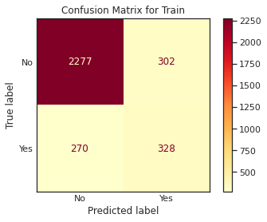

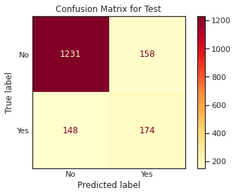

|  | score | train | test |
| --- | --- | --- | --- |
| 0 | Accuracy | 0.819956 | 0.821157 |
| 1 | Recall | 0.548495 | 0.540373 |
| 2 | Precision | 0.520635 | 0.524096 |
| 3 | F1 | 0.534202 | 0.532110 |

```python
#Calculating different metrics
get_metrics_score(dtree_estimator,X_train,X_test,y_train,y_test)
dtree_estimator_model_train_perf=model_performance_classification_sklearn(dtree_estimator,X_train,y_train)
dtree_estimator_model_test_perf=model_performance_classification_sklearn(dtree_estimator,X_test,y_test)
```

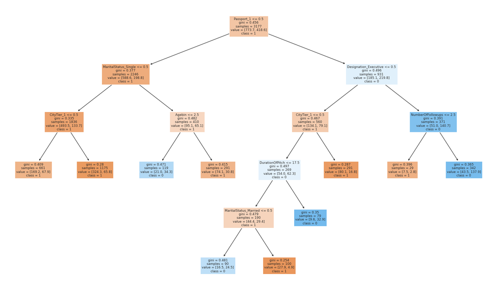

```python
plt.figure(figsize=(25,15))
feature_names = X_train.columns
out = tree.plot_tree(dtree_estimator,feature_names=feature_names,filled=True,fontsize=9,class_names=['1','0'])
for o in out:
    arrow = o.arrow_patch
    if arrow is not None:
        arrow.set_edgecolor('black')
        arrow.set_linewidth(1)
plt.show()
```

### Feature importance of tuned decision tree

```python
# Text report showing the rules of a decision tree -
feature_names = list(X_train.columns)
print(tree.export_text(dtree_estimator,feature_names=feature_names,show_weights=True))
```

```
|--- Passport_1 <= 0.50
|   |--- MaritalStatus_Single <= 0.50
|   |   |--- CityTier_1 <= 0.50
|   |   |   |--- weights: [169.20, 67.90] class: 0
|   |   |--- CityTier_1 >  0.50
|   |   |   |--- weights: [324.30, 65.80] class: 0
|   |--- MaritalStatus_Single >  0.50
|   |   |--- Agebin <= 2.50
|   |   |   |--- weights: [21.00, 34.30] class: 1
|   |   |--- Agebin >  2.50
|   |   |   |--- weights: [74.10, 30.80] class: 0
|--- Passport_1 >  0.50
|   |--- Designation_Executive <= 0.50
|   |   |--- CityTier_1 <= 0.50
|   |   |   |--- DurationOfPitch <= 17.50
|   |   |   |   |--- MaritalStatus_Married <= 0.50
|   |   |   |   |   |--- weights: [16.50, 24.50] class: 1
|   |   |   |   |--- MaritalStatus_Married >  0.50
|   |   |   |   |   |--- weights: [27.90, 4.90] class: 0
|   |   |   |--- DurationOfPitch >  17.50
|   |   |   |   |--- weights: [9.60, 32.90] class: 1
|   |   |--- CityTier_1 >  0.50
|   |   |   |--- weights: [80.10, 16.80] class: 0
|   |--- Designation_Executive >  0.50
|   |   |--- NumberOfFollowups <= 2.50
|   |   |   |--- weights: [7.50, 2.80] class: 0
|   |   |--- NumberOfFollowups >  2.50
|   |   |   |--- weights: [43.50, 137.90] class: 1
```

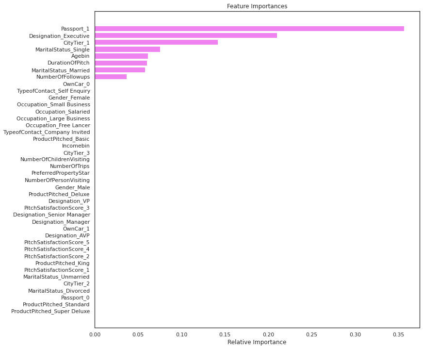

```python
# plot a horizontal bar graph
importances = dtree_estimator.feature_importances_
indices = np.argsort(importances)

plt.figure(figsize=(12, 12))
plt.title("Feature Importances")
plt.barh(range(len(indices)), importances[indices], color="violet", align="center")
plt.yticks(range(len(indices)), [feature_names[i] for i in indices])
plt.xlabel("Relative Importance")
plt.show()
```

- Have passport Passport_1
- Executive level designation
- Tier 1 City
- Marital status single
- Age
- DurationOfPitch
- Marital Status Married
- NumberOfFollowups are the fields which have most importance in the order listed for the Tuned Decision Tree

### Tuning Random Forest

```python
# Choose the type of classifier.
rf_tuned = RandomForestClassifier(random_state=1)

parametersrf = { "max_depth":[5,7,9,15],
               "n_estimators": [15,20,25,50],
               "min_samples_leaf": np.arange(5, 10),
                "max_features": [0.7,0.9,'log2','auto'],
                "class_weight" : [{1:0.6, 0:0.4}, {1:0.7, 0:0.3}, {1:0.8, 0:0.2}, {1:0.5, 0:0.5},'balanced'],
                "max_samples": np.arange(0.3,0.5, 0.7)
              }
# Type of scoring used to compare parameter combinations
scorer = metrics.make_scorer(metrics.f1_score)

# Run the grid search
grid_obj = GridSearchCV(rf_tuned, parametersrf, scoring=scorer,cv=5,n_jobs=-1)
grid_obj = grid_obj.fit(X_train, y_train)

# Set the clf to the best combination of parameters
rf_tuned = grid_obj.best_estimator_

# Fit the best algorithm to the data.
rf_tuned.fit(X_train, y_train)


# Type of scoring used to compare parameter combinations
scorer = metrics.make_scorer(metrics.f1_score)

# Run the grid search
grid_obj = GridSearchCV(rf_tuned, parametersrf, scoring=scorer,cv=5,n_jobs=-1)
grid_obj = grid_obj.fit(X_train, y_train)

# Set the clf to the best combination of parameters
rf_tuned = grid_obj.best_estimator_

# Fit the best algorithm to the data.
rf_tuned.fit(X_train, y_train)
```

```
RandomForestClassifier(class_weight='balanced', max_depth=15, max_samples=0.3,
                       min_samples_leaf=7, n_estimators=20, random_state=1)
```

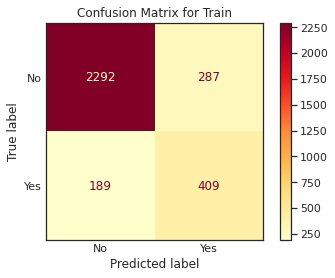

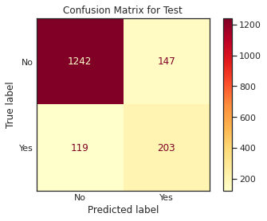

|  | score | train | test |
| --- | --- | --- | --- |
| 0 | Accuracy | 0.850173 | 0.844535 |
| 1 | Recall | 0.683946 | 0.630435 |
| 2 | Precision | 0.587644 | 0.580000 |
| 3 | F1 | 0.632148 | 0.604167 |

```python
#Calculating different metrics
rf_tuned_model_train_perf=model_performance_classification_sklearn(rf_tuned,X_train,y_train)
# print("Training performance:\n",rf_tuned_model_train_perf)
rf_tuned_model_test_perf=model_performance_classification_sklearn(rf_tuned,X_test,y_test)
# print("Testing performance:\n",rf_tuned_model_test_perf)

# rf_tuned_score=
get_metrics_score(rf_tuned,X_train,X_test,y_train,y_test)
# add_score_model(rf_tuned_score)
```

- Random forest has a better value of F1 score 60% test score when compared to Decision Tree.
- Similarly Recall and Accuracy also look better.
- The model is not overfitting and is performing good.

### Feature importance of Tuned Random Forest

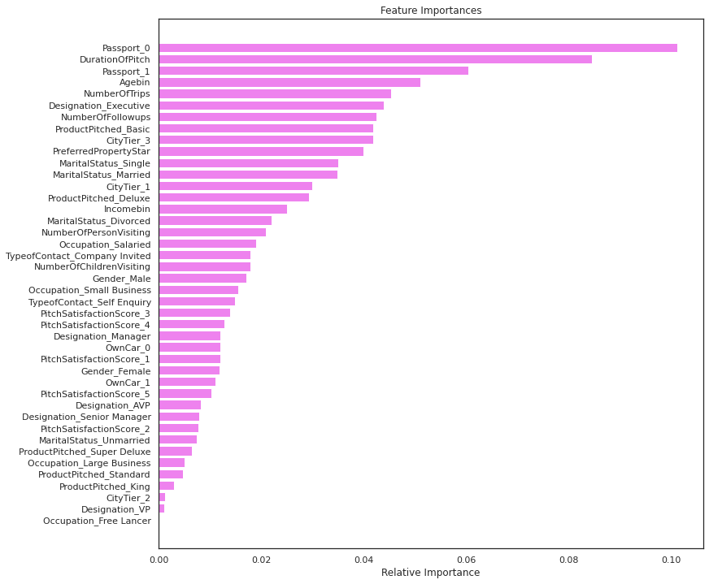

```python
# plot a horizontal bar graph
importances = rf_tuned.feature_importances_
indices = np.argsort(importances)

plt.figure(figsize=(12, 12))
plt.title("Feature Importances")
plt.barh(range(len(indices)), importances[indices], color="violet", align="center")
plt.yticks(range(len(indices)), [feature_names[i] for i in indices])
plt.xlabel("Relative Importance")
plt.show()
```

- We can see that Passport_0, DurationOfPitch,Age,NumberOfTrips, Designation, NumberOfFollowups, ProductPitched_Basic, CityTier_3, PreferredPropertyStar, MaritalStatus_Single are some of the top important features in Tuned Random forest.

### Tuning Bagging Classifier

```python
# Choose the type of classifier.
bagging_estimator_tuned = BaggingClassifier(random_state=1)

# Grid of parameters to choose from
parameters = {'max_samples': [0.7,0.8,0.9,1],
              'max_features': [0.7,0.8,0.9,1],
              'n_estimators' : [10,20,30,40,50],
             }

# Type of scoring used to compare parameter combinations
acc_scorer = metrics.make_scorer(metrics.f1_score)

# Run the grid search
grid_obj = GridSearchCV(bagging_estimator_tuned, parameters, scoring=acc_scorer,cv=5)
grid_obj = grid_obj.fit(X_train, y_train)

# Set the clf to the best combination of parameters
bagging_estimator_tuned = grid_obj.best_estimator_

# Fit the best algorithm to the data.
bagging_estimator_tuned.fit(X_train, y_train)
```

```
BaggingClassifier(max_features=0.9, max_samples=0.9, n_estimators=50,
                  random_state=1)
```

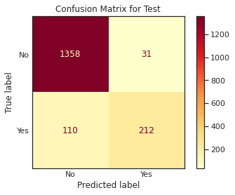

|  | score | train | test |
| --- | --- | --- | --- |
| 0 | Accuracy | 1.0 | 0.917592 |
| 1 | Recall | 1.0 | 0.658385 |
| 2 | Precision | 1.0 | 0.872428 |
| 3 | F1 | 1.0 | 0.750442 |

```python
# Create confusion metrics and print scores
get_metrics_score(bagging_estimator_tuned,X_train,X_test,y_train,y_test)
#Calculating different metrics
bagging_estimator_tuned_model_train_perf=model_performance_classification_sklearn(bagging_estimator_tuned,X_train,y_train)
bagging_estimator_tuned_model_test_perf=model_performance_classification_sklearn(bagging_estimator_tuned,X_test,y_test)
```

- There is a huge difference between Train and Test sets which means the model is overfitting.

## Comparing all the models

```python
# training performance comparison
models_train_comp_df = pd.concat(
    [dtree_model_train_perf.T,dtree_estimator_model_train_perf.T,rf_estimator_model_train_perf.T,rf_tuned_model_train_perf.T,
     bagging_classifier_model_train_perf.T,bagging_estimator_tuned_model_train_perf.T],
    axis=1,
)
models_train_comp_df.columns = [
    "Decision Tree",
    "Decision Tree Estimator",
    "Random Forest Estimator",
    "Random Forest Tuned",
    "Bagging Classifier",
    "Bagging Estimator Tuned"]
```

```python
# testing performance comparison
models_test_comp_df = pd.concat(
    [dtree_model_test_perf.T,dtree_estimator_model_test_perf.T,rf_estimator_model_test_perf.T,rf_tuned_model_test_perf.T,
     bagging_classifier_model_test_perf.T, bagging_estimator_tuned_model_test_perf.T],
    axis=1,
)
models_test_comp_df.columns = [
    "Decision Tree",
    "Decision Tree Estimator",
    "Random Forest Estimator",
    "Random Forest Tuned",
    "Bagging Classifier",
    "Bagging Estimator Tuned"]
```

```python
print("Training performance comparison:")
models_train_comp_df
```

```
Training performance comparison:
```

|  | Decision Tree | Decision Tree Estimator | Random Forest Estimator | Random Forest Tuned | Bagging Classifier | Bagging Estimator Tuned |
| --- | --- | --- | --- | --- | --- | --- |
| Accuracy | 1.0 | 0.819956 | 1.0 | 0.850173 | 0.993390 | 1.0 |
| Recall | 1.0 | 0.548495 | 1.0 | 0.683946 | 0.969900 | 1.0 |
| Precision | 1.0 | 0.520635 | 1.0 | 0.587644 | 0.994854 | 1.0 |
| F1 | 1.0 | 0.534202 | 1.0 | 0.632148 | 0.982218 | 1.0 |

```python
print("Testing performance comparison:")
models_test_comp_df
```

```
Testing performance comparison:
```

|  | Decision Tree | Decision Tree Estimator | Random Forest Estimator | Random Forest Tuned | Bagging Classifier | Bagging Estimator Tuned |
| --- | --- | --- | --- | --- | --- | --- |
| Accuracy | 0.902396 | 0.821157 | 0.917008 | 0.844535 | 0.905319 | 0.917592 |
| Recall | 0.767081 | 0.540373 | 0.627329 | 0.630435 | 0.596273 | 0.658385 |
| Precision | 0.728614 | 0.524096 | 0.901786 | 0.580000 | 0.857143 | 0.872428 |
| F1 | 0.747352 | 0.532110 | 0.739927 | 0.604167 | 0.703297 | 0.750442 |

- Out of all the 3 models, Tuned random forest with test F1 score of 60% and Tuned Decision Tree with Test F1 score of 53% seem to be having a better model prediction.

## AdaBoost Classifier

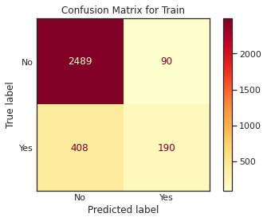

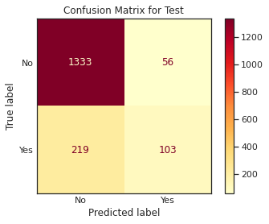

|  | score | train | test |
| --- | --- | --- | --- |
| 0 | Accuracy | 0.843248 | 0.839275 |
| 1 | Recall | 0.317726 | 0.319876 |
| 2 | Precision | 0.678571 | 0.647799 |
| 3 | F1 | 0.432802 | 0.428274 |

```python
#Fitting the model
ab_classifier = AdaBoostClassifier(random_state=1)
ab_classifier.fit(X_train,y_train)

get_metrics_score(ab_classifier,X_train,X_test,y_train,y_test)

#Calculating different metrics
ab_classifier_model_train_perf=model_performance_classification_sklearn(ab_classifier,X_train,y_train)
ab_classifier_model_test_perf=model_performance_classification_sklearn(ab_classifier,X_test,y_test)
```

- Adaboost is giving more generalized performance than previous models but the test f1-score is too low.

### Hyperparameter Tuning

```python
# Choose the type of classifier.
abc_tuned = AdaBoostClassifier(random_state=1)

# Grid of parameters to choose from
parameters = {
    #Let's try different max_depth for base_estimator
    "base_estimator":[DecisionTreeClassifier(max_depth=1),DecisionTreeClassifier(max_depth=2),
                      DecisionTreeClassifier(max_depth=3)],
    "n_estimators": np.arange(10,20,30),
    "learning_rate":np.arange(0.1,2,0.1)
}

# Type of scoring used to compare parameter  combinations
scorer = metrics.make_scorer(metrics.f1_score)

# Run the grid search
grid_obj = GridSearchCV(abc_tuned, parameters, scoring=scorer,cv=5)
grid_obj = grid_obj.fit(X_train, y_train)

# Set the clf to the best combination of parameters
abc_tuned = grid_obj.best_estimator_

# Fit the best algorithm to the data.
abc_tuned.fit(X_train, y_train)
```

```
AdaBoostClassifier(base_estimator=DecisionTreeClassifier(max_depth=1),
                   learning_rate=1.8000000000000003, n_estimators=10,
                   random_state=1)
```

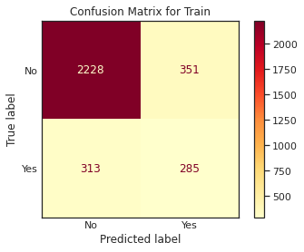

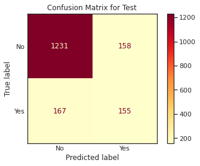

|  | score | train | test |
| --- | --- | --- | --- |
| 0 | Accuracy | 0.790998 | 0.810053 |
| 1 | Recall | 0.476589 | 0.481366 |
| 2 | Precision | 0.448113 | 0.495208 |
| 3 | F1 | 0.461912 | 0.488189 |

```python
#Creating confusion matrix and print scores
get_metrics_score(abc_tuned,X_train,X_test,y_train,y_test)

#Calculating different metrics
abc_tuned_model_train_perf=model_performance_classification_sklearn(abc_tuned,X_train,y_train)
abc_tuned_model_test_perf=model_performance_classification_sklearn(abc_tuned,X_test,y_test)
```

- The model performance has increased slightly but the test score is higher than the training score.

## Gradient Boosting Classifier

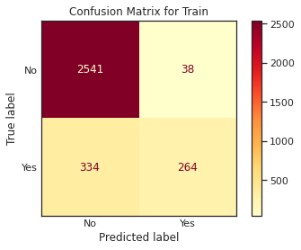

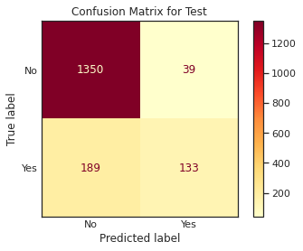

|  | score | train | test |
| --- | --- | --- | --- |
| 0 | Accuracy | 0.882908 | 0.866745 |
| 1 | Recall | 0.441472 | 0.413043 |
| 2 | Precision | 0.874172 | 0.773256 |
| 3 | F1 | 0.586667 | 0.538462 |

```python
#Fitting the model
gb_classifier = GradientBoostingClassifier(random_state=1)
gb_classifier.fit(X_train,y_train)
#Creating confusion matrix and print scores
get_metrics_score(gb_classifier,X_train,X_test,y_train,y_test)

#Calculating different metrics
gb_classifier_model_train_perf=model_performance_classification_sklearn(gb_classifier,X_train,y_train)
gb_classifier_model_test_perf=model_performance_classification_sklearn(gb_classifier,X_test,y_test)
```

- F1 score has improved with Gradient boosting, recall value is low.

### Hyperparameter Tuning

```python
# Choose the type of classifier.
gbc_tuned = GradientBoostingClassifier(init=AdaBoostClassifier(random_state=1),random_state=1)

# Grid of parameters to choose from
parameters = {
    "n_estimators": [10,15,20,25],
    "subsample":[0.8,0.9,1],
    "max_features":[0.7,0.8,0.9,1]
}

# Type of scoring used to compare parameter combinations
scorer = metrics.make_scorer(metrics.f1_score)

# Run the grid search
grid_obj = GridSearchCV(gbc_tuned, parameters, scoring=scorer,cv=5)
grid_obj = grid_obj.fit(X_train, y_train)

# Set the clf to the best combination of parameters
gbc_tuned = grid_obj.best_estimator_

# Fit the best algorithm to the data.
gbc_tuned.fit(X_train, y_train)
```

```
GradientBoostingClassifier(init=AdaBoostClassifier(random_state=1),
                           max_features=0.8, n_estimators=25, random_state=1,
                           subsample=1)
```

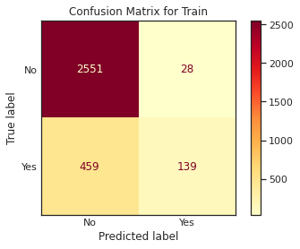

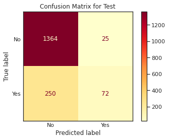

|  | score | train | test |
| --- | --- | --- | --- |
| 0 | Accuracy | 0.846711 | 0.839275 |
| 1 | Recall | 0.232441 | 0.223602 |
| 2 | Precision | 0.832335 | 0.742268 |
| 3 | F1 | 0.363399 | 0.343675 |

```python
#Creating confusion matrix and print scores
get_metrics_score(gbc_tuned,X_train,X_test,y_train,y_test)

#Calculating different metrics
gbc_tuned_model_train_perf=model_performance_classification_sklearn(gbc_tuned,X_train,y_train)
gbc_tuned_model_test_perf=model_performance_classification_sklearn(gbc_tuned,X_test,y_test)
```

- F1 score has reduced after hyperparameter tuning. The model is not performing good.

## XGBoost Classifier

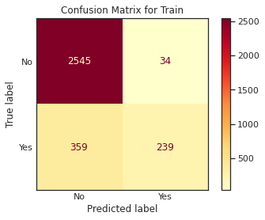

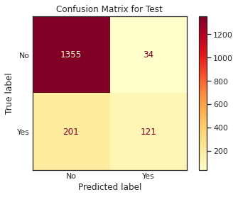

|  | score | train | test |
| --- | --- | --- | --- |
| 0 | Accuracy | 0.876298 | 0.862653 |
| 1 | Recall | 0.399666 | 0.375776 |
| 2 | Precision | 0.875458 | 0.780645 |
| 3 | F1 | 0.548794 | 0.507338 |

```python
#Fitting the model
xgb_classifier = XGBClassifier(random_state=1, eval_metric='logloss')
xgb_classifier.fit(X_train,y_train)

#Creating confusion matrix and print scores
get_metrics_score(xgb_classifier,X_train,X_test,y_train,y_test)

#Calculating different metrics
xgb_classifier_model_train_perf=model_performance_classification_sklearn(xgb_classifier,X_train,y_train)
xgb_classifier_model_test_perf=model_performance_classification_sklearn(xgb_classifier,X_test,y_test)
```

### Hyperparameter Tuning

```python
# Choose the type of classifier.
xgb_tuned = XGBClassifier(random_state=1, eval_metric='logloss')

# Grid of parameters to choose from
parameters = {
    "n_estimators": [10,30,50],
    "scale_pos_weight":[1,2,5],
    "subsample":[0.7,0.9,1],
    "learning_rate":[0.05, 0.1,0.2],
    "colsample_bytree":[0.7,0.9,1],
    "colsample_bylevel":[0.5,0.7,1]
}

# Type of scoring used to compare parameter combinations
scorer = metrics.make_scorer(metrics.f1_score)

# Run the grid search
grid_obj = GridSearchCV(xgb_tuned, parameters,scoring=scorer,cv=5)
grid_obj = grid_obj.fit(X_train, y_train)

# Set the clf to the best combination of parameters
xgb_tuned = grid_obj.best_estimator_

# Fit the best algorithm to the data.

xgb_tuned.fit(X_train, y_train)
```

```
XGBClassifier(colsample_bylevel=0.7, eval_metric='logloss', learning_rate=0.2,
              n_estimators=50, random_state=1, scale_pos_weight=2,
              subsample=0.7)
```

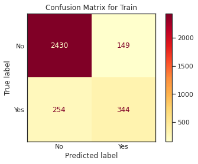

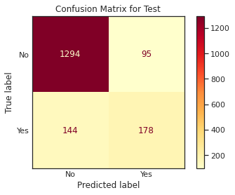

|  | score | train | test |
| --- | --- | --- | --- |
| 0 | Accuracy | 0.873151 | 0.860316 |
| 1 | Recall | 0.575251 | 0.552795 |
| 2 | Precision | 0.697769 | 0.652015 |
| 3 | F1 | 0.630614 | 0.598319 |

```python
#Creating confusion matrix and print scores
get_metrics_score(xgb_tuned,X_train,X_test,y_train,y_test)

#Calculating different metrics
xgb_tuned_model_train_perf=model_performance_classification_sklearn(xgb_tuned,X_train,y_train)
xgb_tuned_model_test_perf=model_performance_classification_sklearn(xgb_tuned,X_test,y_test)
```

## Stacking Classifier

```python
estimators = [('Random Forest',rf_tuned), ('XGB Tuned',xgb_tuned), ('Decision Tree',dtree_estimator)
, ('Ada Boost',abc_tuned)]

final_estimator = xgb_tuned

stacking_classifier= StackingClassifier(estimators=estimators,final_estimator=final_estimator)

stacking_classifier.fit(X_train,y_train)
```

```
StackingClassifier(estimators=[('Random Forest',
                                RandomForestClassifier(class_weight='balanced',
                                                       max_depth=15,
                                                       max_samples=0.3,
                                                       min_samples_leaf=7,
                                                       n_estimators=20,
                                                       random_state=1)),
                               ('XGB Tuned',
                                XGBClassifier(colsample_bylevel=0.7,
                                              eval_metric='logloss',
                                              learning_rate=0.2,
                                              n_estimators=50, random_state=1,
                                              scale_pos_weight=2,
                                              subsample=0.7)),
                               ('Decision Tree',
                                Decis...
                                                       min_impurity_decrease=0.0001,
                                                       random_state=1)),
                               ('Ada Boost',
                                AdaBoostClassifier(base_estimator=DecisionTreeClassifier(max_depth=1),
                                                   learning_rate=1.8000000000000003,
                                                   n_estimators=10,
                                                   random_state=1))],
                   final_estimator=XGBClassifier(colsample_bylevel=0.7,
                                                 eval_metric='logloss',
                                                 learning_rate=0.2,
                                                 n_estimators=50,
                                                 random_state=1,
                                                 scale_pos_weight=2,
                                                 subsample=0.7))
```

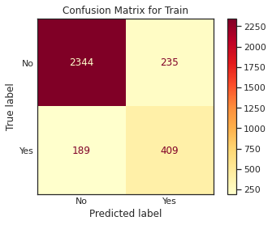

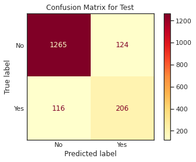

|  | score | train | test |
| --- | --- | --- | --- |
| 0 | Accuracy | 0.866541 | 0.859731 |
| 1 | Recall | 0.683946 | 0.639752 |
| 2 | Precision | 0.635093 | 0.624242 |
| 3 | F1 | 0.658615 | 0.631902 |

```python
#Creating confusion matrix and print scores
get_metrics_score(stacking_classifier,X_train,X_test,y_train,y_test)

#Calculating different metrics
stacking_classifier_model_train_perf=model_performance_classification_sklearn(stacking_classifier,X_train,y_train)
stacking_classifier_model_test_perf=model_performance_classification_sklearn(stacking_classifier,X_test,y_test)
```

## Comparing all models

```python
# training performance comparison

models_comp_df = pd.concat([dtree_model_train_perf.T
                            ,dtree_model_test_perf.T
                            ,dtree_estimator_model_train_perf.T
                            ,dtree_estimator_model_test_perf.T
     ,rf_estimator_model_train_perf.T
     ,rf_estimator_model_test_perf.T
     ,rf_tuned_model_train_perf.T
     ,rf_tuned_model_test_perf.T
     ,bagging_classifier_model_train_perf.T
     ,bagging_classifier_model_test_perf.T
     ,bagging_estimator_tuned_model_train_perf.T
     ,bagging_estimator_tuned_model_test_perf.T
     ,ab_classifier_model_train_perf.T
     ,ab_classifier_model_test_perf.T
     ,abc_tuned_model_train_perf.T
     ,abc_tuned_model_test_perf.T
     ,gb_classifier_model_train_perf.T
     ,gb_classifier_model_test_perf.T
     ,gbc_tuned_model_train_perf.T
     ,gbc_tuned_model_test_perf.T
     ,xgb_classifier_model_train_perf.T
     ,xgb_classifier_model_test_perf.T
     ,xgb_tuned_model_train_perf.T
     ,xgb_tuned_model_test_perf.T
     ,stacking_classifier_model_train_perf.T
     ,stacking_classifier_model_test_perf.T],axis=1,
)
models_comp_df.columns = [
    "Decision Tree",
    "Decision Tree Test",
    "Decision Tree Estimator",
    "Decision Tree Estimator Test",
    "Random Forest Estimator",
    "Random Forest Estimator Test",
    "Random Forest Tuned",
    "Random Forest Tuned Test",
    "Bagging Classifier",
    "Bagging Classifier Test",
    "Bagging Estimator Tuned",
    "Bagging Estimator Tuned Test",
    "Adaboost Classifier",
    "Adaboost Classifier Test",
    "Adabosst Classifier Tuned",
    "Adabosst Classifier Tuned Test",
    "Gradient Boost Classifier",
    "Gradient Boost Classifier Test",
    "Gradient Boost Classifier Tuned",
    "Gradient Boost Classifier Tuned Test",
    "XGBoost Classifier",
    "XGBoost Classifier Test",
    "XGBoost Classifier Tuned",
    "XGBoost Classifier Tuned Test",
    "Stacking Classifier","Stacking Classifier Test"]
print("Training performance comparison:")
models_comp_df.T
```

```
Training performance comparison:
```

|  | Accuracy | Recall | Precision | F1 |
| --- | --- | --- | --- | --- |
| Decision Tree | 1.000000 | 1.000000 | 1.000000 | 1.000000 |
| Decision Tree Test | 0.902396 | 0.767081 | 0.728614 | 0.747352 |
| Decision Tree Estimator | 0.819956 | 0.548495 | 0.520635 | 0.534202 |
| Decision Tree Estimator Test | 0.821157 | 0.540373 | 0.524096 | 0.532110 |
| Random Forest Estimator | 1.000000 | 1.000000 | 1.000000 | 1.000000 |
| Random Forest Estimator Test | 0.917008 | 0.627329 | 0.901786 | 0.739927 |
| Random Forest Tuned | 0.850173 | 0.683946 | 0.587644 | 0.632148 |
| Random Forest Tuned Test | 0.844535 | 0.630435 | 0.580000 | 0.604167 |
| Bagging Classifier | 0.993390 | 0.969900 | 0.994854 | 0.982218 |
| Bagging Classifier Test | 0.905319 | 0.596273 | 0.857143 | 0.703297 |
| Bagging Estimator Tuned | 1.000000 | 1.000000 | 1.000000 | 1.000000 |
| Bagging Estimator Tuned Test | 0.917592 | 0.658385 | 0.872428 | 0.750442 |
| Adaboost Classifier | 0.843248 | 0.317726 | 0.678571 | 0.432802 |
| Adaboost Classifier Test | 0.839275 | 0.319876 | 0.647799 | 0.428274 |
| Adabosst Classifier Tuned | 0.790998 | 0.476589 | 0.448113 | 0.461912 |
| Adabosst Classifier Tuned Test | 0.810053 | 0.481366 | 0.495208 | 0.488189 |
| Gradient Boost Classifier | 0.882908 | 0.441472 | 0.874172 | 0.586667 |
| Gradient Boost Classifier Test | 0.866745 | 0.413043 | 0.773256 | 0.538462 |
| Gradient Boost Classifier Tuned | 0.846711 | 0.232441 | 0.832335 | 0.363399 |
| Gradient Boost Classifier Tuned Test | 0.839275 | 0.223602 | 0.742268 | 0.343675 |
| XGBoost Classifier | 0.876298 | 0.399666 | 0.875458 | 0.548794 |
| XGBoost Classifier Test | 0.862653 | 0.375776 | 0.780645 | 0.507338 |
| XGBoost Classifier Tuned | 0.873151 | 0.575251 | 0.697769 | 0.630614 |
| XGBoost Classifier Tuned Test | 0.860316 | 0.552795 | 0.652015 | 0.598319 |
| Stacking Classifier | 0.866541 | 0.683946 | 0.635093 | 0.658615 |
| Stacking Classifier Test | 0.859731 | 0.639752 | 0.624242 | 0.631902 |

## Business Insights and Recommendations

The goal of this model building is to identify the right segment of customers to market the newly introduced travel package 'Welness Tourism'.

Inorder to attract more customers from buying this package, marketing team should refer to the trend in customers buying the travel package as described above.

Company can introduce some services to customers with children, eg: providing some art kit or some sort of activites for kids as part of the wellness package to attract the customers travelling with kids to purchase the newly introduced travel package.

The marketing team can create the separate packages for customers in different income group, age and designation.

The marketing team can create product and customer segment specific sale pitch to reduce the DurationOfPitch.

The company can run various campaigns and offers for customers with family to increase sales.

The data collection process can be enhanced to capture additional information like customer satisfaction post tour and data to correlate the product pitched to the product actually purchased by customers.

Targetting the right customers will reduce the marketing cost to the company and allow more customers to purchase the travel package.

Company can also introduce buddy pass promotion for friends and relatives of customers and provide discounts for existing customers as a referral bonus.